# INN Hotels Project

## Context

A significant number of hotel bookings are called-off due to cancellations or no-shows. The typical reasons for cancellations include change of plans, scheduling conflicts, etc. This is often made easier by the option to do so free of charge or preferably at a low cost which is beneficial to hotel guests but it is a less desirable and possibly revenue-diminishing factor for hotels to deal with. Such losses are particularly high on last-minute cancellations.

The new technologies involving online booking channels have dramatically changed customers’ booking possibilities and behavior. This adds a further dimension to the challenge of how hotels handle cancellations, which are no longer limited to traditional booking and guest characteristics.

The cancellation of bookings impact a hotel on various fronts:

- Loss of resources (revenue) when the hotel cannot resell the room.
- Additional costs of distribution channels by increasing commissions or paying for publicity to help sell these rooms.
- Lowering prices last minute, so the hotel can resell a room, resulting in reducing the profit margin.
- Human resources to make arrangements for the guests.

## Objective

The increasing number of cancellations calls for a Machine Learning based solution that can help in predicting which booking is likely to be canceled. INN Hotels Group has a chain of hotels in Portugal, they are facing problems with the high number of booking cancellations and have reached out to your firm for data-driven solutions. You as a data scientist have to analyze the data provided to find which factors have a high influence on booking cancellations, build a predictive model that can predict which booking is going to be canceled in advance, and help in formulating profitable policies for cancellations and refunds.

## Data Description

The data contains the different attributes of customers' booking details. The detailed data dictionary is given below.

**Data Dictionary**

- Booking_ID: unique identifier of each booking
- no_of_adults: Number of adults
- no_of_children: Number of Children
- no_of_weekend_nights: Number of weekend nights (Saturday or Sunday) the guest stayed or booked to stay at the hotel
- no_of_week_nights: Number of week nights (Monday to Friday) the guest stayed or booked to stay at the hotel
- type_of_meal_plan: Type of meal plan booked by the customer:
  - Not Selected – No meal plan selected
  - Meal Plan 1 – Breakfast
  - Meal Plan 2 – Half board (breakfast and one other meal)
  - Meal Plan 3 – Full board (breakfast, lunch, and dinner)
- required_car_parking_space: Does the customer require a car parking space? (0 - No, 1- Yes)
- room_type_reserved: Type of room reserved by the customer. The values are ciphered (encoded) by INN Hotels.
- lead_time: Number of days between the date of booking and the arrival date
- arrival_year: Year of arrival date
- arrival_month: Month of arrival date
- arrival_date: Date of the month
- market_segment_type: Market segment designation.
- repeated_guest: Is the customer a repeated guest? (0 - No, 1- Yes)
- no_of_previous_cancellations: Number of previous bookings that were canceled by the customer prior to the current booking
- no_of_previous_bookings_not_canceled: Number of previous bookings not canceled by the customer prior to the current booking
- avg_price_per_room: Average price per day of the reservation; prices of the rooms are dynamic. (in euros)
- no_of_special_requests: Total number of special requests made by the customer (e.g. high floor, view from the room, etc)
- booking_status: Flag indicating if the booking was canceled or not.

## Importing necessary libraries and data

```python
# this will help in making the Python code more structured automatically (help adhere to good coding practices)
%load_ext nb_black

import warnings

warnings.filterwarnings("ignore")
from statsmodels.tools.sm_exceptions import ConvergenceWarning

warnings.simplefilter("ignore", ConvergenceWarning)

# Libraries to help with reading and manipulating data
import pandas as pd
import numpy as np

# libaries to help with data visualization
import matplotlib.pyplot as plt
import seaborn as sns

# Library to split data
from sklearn.model_selection import train_test_split

# To build model for prediction
import statsmodels.stats.api as sms
from statsmodels.stats.outliers_influence import variance_inflation_factor
import statsmodels.api as sm
from statsmodels.tools.tools import add_constant
from sklearn.preprocessing import LabelEncoder
from sklearn.linear_model import LogisticRegression
from sklearn.tree import DecisionTreeClassifier
from sklearn import tree

# To tune different models
from sklearn.model_selection import GridSearchCV

# To get diferent metric scores
from sklearn.metrics import (
    f1_score,
    classification_report,
    accuracy_score,
    recall_score,
    precision_score,
    confusion_matrix,
    roc_auc_score,
    plot_confusion_matrix,
    precision_recall_curve,
    roc_curve,
    make_scorer,
)
```

```
The nb_black extension is already loaded. To reload it, use:
  %reload_ext nb_black
```

## Data Overview

- Observations
- Sanity checks

```python
data = pd.read_csv(r'INNHotelsGroup.csv') ##  Fill the blank to read the data
```

```python
data.head() #view the first 5 rows of the data
```

|  | Booking_ID | no_of_adults | no_of_children | no_of_weekend_nights | no_of_week_nights | type_of_meal_plan | required_car_parking_space | room_type_reserved | lead_time | arrival_year | arrival_month | arrival_date | market_segment_type | repeated_guest | no_of_previous_cancellations | no_of_previous_bookings_not_canceled | avg_price_per_room | no_of_special_requests | booking_status |
| --- | --- | --- | --- | --- | --- | --- | --- | --- | --- | --- | --- | --- | --- | --- | --- | --- | --- | --- | --- |
| 0 | INN00001 | 2 | 0 | 1 | 2 | Meal Plan 1 | 0 | Room_Type 1 | 224 | 2017 | 10 | 2 | Offline | 0 | 0 | 0 | 65.00 | 0 | Not_Canceled |
| 1 | INN00002 | 2 | 0 | 2 | 3 | Not Selected | 0 | Room_Type 1 | 5 | 2018 | 11 | 6 | Online | 0 | 0 | 0 | 106.68 | 1 | Not_Canceled |
| 2 | INN00003 | 1 | 0 | 2 | 1 | Meal Plan 1 | 0 | Room_Type 1 | 1 | 2018 | 2 | 28 | Online | 0 | 0 | 0 | 60.00 | 0 | Canceled |
| 3 | INN00004 | 2 | 0 | 0 | 2 | Meal Plan 1 | 0 | Room_Type 1 | 211 | 2018 | 5 | 20 | Online | 0 | 0 | 0 | 100.00 | 0 | Canceled |
| 4 | INN00005 | 2 | 0 | 1 | 1 | Not Selected | 0 | Room_Type 1 | 48 | 2018 | 4 | 11 | Online | 0 | 0 | 0 | 94.50 | 0 | Canceled |

```python
data.info()
```

```
<class 'pandas.core.frame.DataFrame'>
RangeIndex: 36275 entries, 0 to 36274
Data columns (total 19 columns):
 #   Column                                Non-Null Count  Dtype
---  ------                                --------------  -----
 0   Booking_ID                            36275 non-null  object
 1   no_of_adults                          36275 non-null  int64
 2   no_of_children                        36275 non-null  int64
 3   no_of_weekend_nights                  36275 non-null  int64
 4   no_of_week_nights                     36275 non-null  int64
 5   type_of_meal_plan                     36275 non-null  object
 6   required_car_parking_space            36275 non-null  int64
 7   room_type_reserved                    36275 non-null  object
 8   lead_time                             36275 non-null  int64
 9   arrival_year                          36275 non-null  int64
 10  arrival_month                         36275 non-null  int64
 11  arrival_date                          36275 non-null  int64
 12  market_segment_type                   36275 non-null  object
 13  repeated_guest                        36275 non-null  int64
 14  no_of_previous_cancellations          36275 non-null  int64
 15  no_of_previous_bookings_not_canceled  36275 non-null  int64
 16  avg_price_per_room                    36275 non-null  float64
 17  no_of_special_requests                36275 non-null  int64
 18  booking_status                        36275 non-null  object
dtypes: float64(1), int64(13), object(5)
memory usage: 5.3+ MB
```

```python
#view the descriptive statistics of the data
data.describe()
```

|  | no_of_adults | no_of_children | no_of_weekend_nights | no_of_week_nights | required_car_parking_space | lead_time | arrival_year | arrival_month | arrival_date | repeated_guest | no_of_previous_cancellations | no_of_previous_bookings_not_canceled | avg_price_per_room | no_of_special_requests |
| --- | --- | --- | --- | --- | --- | --- | --- | --- | --- | --- | --- | --- | --- | --- |
| count | 36275.000000 | 36275.000000 | 36275.000000 | 36275.000000 | 36275.000000 | 36275.000000 | 36275.000000 | 36275.000000 | 36275.000000 | 36275.000000 | 36275.000000 | 36275.000000 | 36275.000000 | 36275.000000 |
| mean | 1.844962 | 0.105279 | 0.810724 | 2.204300 | 0.030986 | 85.232557 | 2017.820427 | 7.423653 | 15.596995 | 0.025637 | 0.023349 | 0.153411 | 103.423539 | 0.619655 |
| std | 0.518715 | 0.402648 | 0.870644 | 1.410905 | 0.173281 | 85.930817 | 0.383836 | 3.069894 | 8.740447 | 0.158053 | 0.368331 | 1.754171 | 35.089424 | 0.786236 |
| min | 0.000000 | 0.000000 | 0.000000 | 0.000000 | 0.000000 | 0.000000 | 2017.000000 | 1.000000 | 1.000000 | 0.000000 | 0.000000 | 0.000000 | 0.000000 | 0.000000 |
| 25% | 2.000000 | 0.000000 | 0.000000 | 1.000000 | 0.000000 | 17.000000 | 2018.000000 | 5.000000 | 8.000000 | 0.000000 | 0.000000 | 0.000000 | 80.300000 | 0.000000 |
| 50% | 2.000000 | 0.000000 | 1.000000 | 2.000000 | 0.000000 | 57.000000 | 2018.000000 | 8.000000 | 16.000000 | 0.000000 | 0.000000 | 0.000000 | 99.450000 | 0.000000 |
| 75% | 2.000000 | 0.000000 | 2.000000 | 3.000000 | 0.000000 | 126.000000 | 2018.000000 | 10.000000 | 23.000000 | 0.000000 | 0.000000 | 0.000000 | 120.000000 | 1.000000 |
| max | 4.000000 | 10.000000 | 7.000000 | 17.000000 | 1.000000 | 443.000000 | 2018.000000 | 12.000000 | 31.000000 | 1.000000 | 13.000000 | 58.000000 | 540.000000 | 5.000000 |

```python
# checking for duplicate values
data.duplicated().any()
```

```
False
```

## Exploratory Data Analysis (EDA)

- EDA is an important part of any project involving data.
- It is important to investigate and understand the data better before building a model with it.
- A few questions have been mentioned below which will help you approach the analysis in the right manner and generate insights from the data.
- A thorough analysis of the data, in addition to the questions mentioned below, should be done.

**Leading Questions**:

1. What are the busiest months in the hotel?
2. Which market segment do most of the guests come from?
3. Hotel rates are dynamic and change according to demand and customer demographics. What are the differences in room prices in different market segments?
4. What percentage of bookings are canceled?
5. Repeating guests are the guests who stay in the hotel often and are important to brand equity. What percentage of repeating guests cancel?
6. Many guests have special requirements when booking a hotel room. Do these requirements affect booking cancellation?

## What are the busiest months in the hotel?

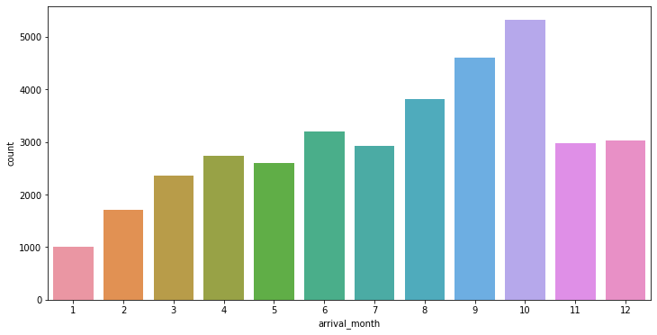

```python
plt.figure(figsize=(12,6))
sns.countplot(data['arrival_month'])
```

## Which market segment do most of the guests come from?

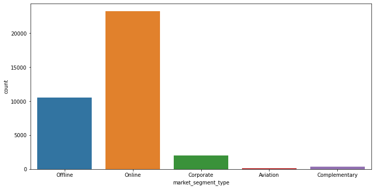

```python
plt.figure(figsize=(12,6))
sns.countplot(data['market_segment_type'])
```

## Hotel rates are dynamic and change according to demand and customer demographics. What are the differences in room prices in different market segments?

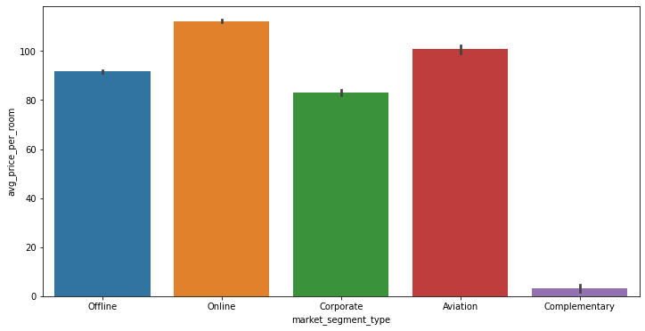

```python
plt.figure(figsize=(12,6))
sns.barplot(x='market_segment_type', y='avg_price_per_room', data=data)
```

## What percentage of bookings are canceled?

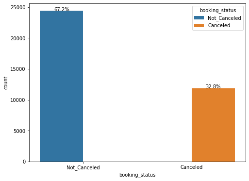

```python
plt.figure(figsize=(8,6))

total = float(len(data))

ax = sns.countplot(x="booking_status", hue="booking_status", data=data)

for p in ax.patches:
    percentage = '{:.1f}%'.format(100 * p.get_height()/total)
    x = p.get_x() + 0.2
    y = p.get_height()+0.1
    ax.annotate(percentage, (x, y),ha='center')
```

## Repeating guests are the guests who stay in the hotel often and are important to brand equity. What percentage of repeating guests cancel?

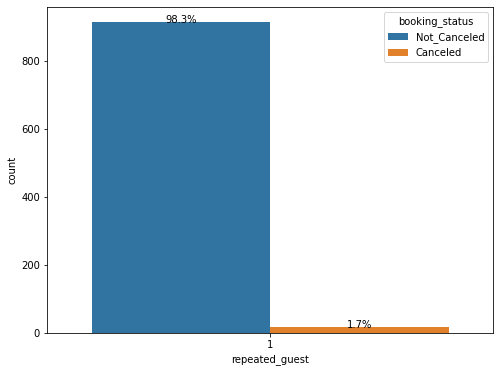

```python
plt.figure(figsize=(8,6))

total = float(len(data[data['repeated_guest'] == 1]))

ax = sns.countplot(x="repeated_guest", hue="booking_status", data=data[data['repeated_guest'] == 1])

for p in ax.patches:
    percentage = '{:.1f}%'.format(100 * p.get_height()/total)
    x = p.get_x() + 0.2
    y = p.get_height()+0.1
    ax.annotate(percentage, (x, y),ha='center')
```

## Many guests have special requirements when booking a hotel room. Do these requirements affect booking cancellation?

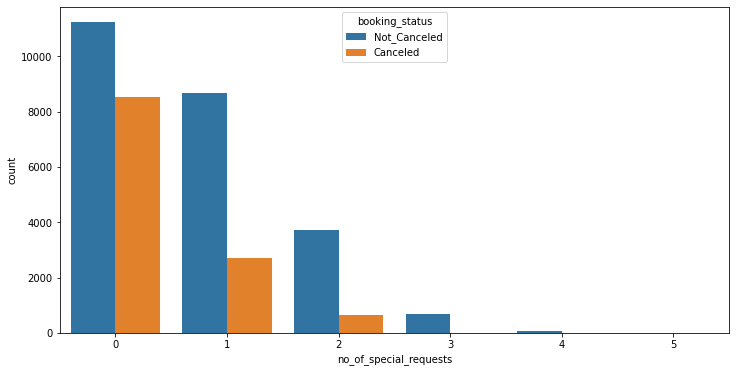

```python
plt.figure(figsize=(12,6))
sns.countplot(x='no_of_special_requests', hue='booking_status', data=data)
```

## Data Preprocessing

- Missing value treatment (if needed)
- Feature engineering (if needed)
- Outlier detection and treatment (if needed)
- Preparing data for modeling
- Any other preprocessing steps (if needed)

```python
#Check for missing value
data.isnull().sum().any()
```

```
False
```

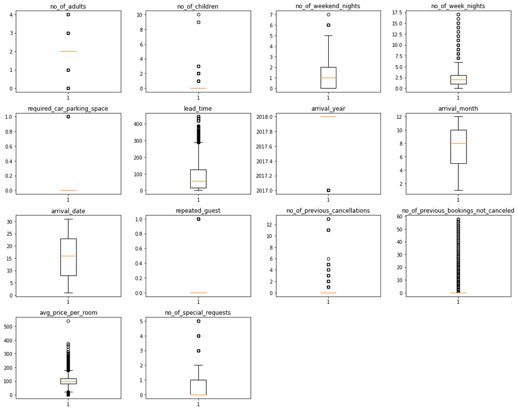

```python
# outlier detection using boxplot
numeric_columns = data.select_dtypes(include=np.number).columns.tolist()

plt.figure(figsize=(15, 12))

for i, variable in enumerate(numeric_columns):
    plt.subplot(4, 4, i + 1)
    plt.boxplot(data[variable], whis=1.5)
    plt.tight_layout()
    plt.title(variable)

plt.show()
```

## EDA

- It is a good idea to explore the data once again after manipulating it.

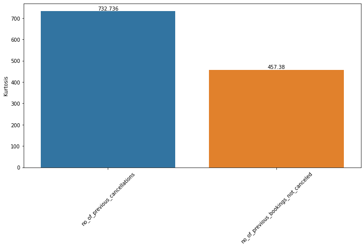

```python
#Visualize fearures with high Kurtosis
a = new_df[new_df['Kurtosis']>70]
fig = plt.figure(figsize = (12,6))
ax = sns.barplot(x = a.index, y='Kurtosis',data=a)
ax.bar_label(ax.containers[0])
labels = plt.xticks(rotation=45)
```

[output not shown]

## Checking Multicollinearity

- In order to make statistical inferences from a logistic regression model, it is important to ensure that there is no multicollinearity present in the data.

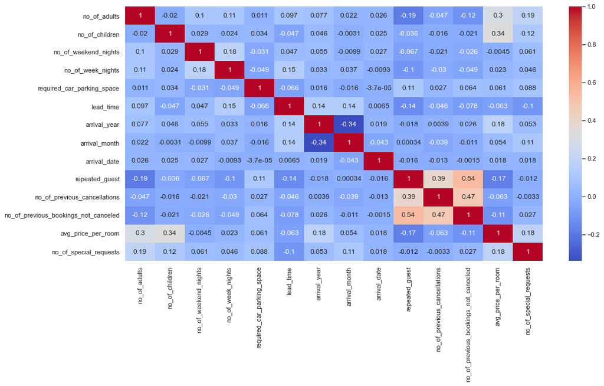

```python
sns.set(rc = {'figure.figsize':(16,8)})
sns.heatmap(data.corr(), annot = True, fmt='.2g',cmap= 'coolwarm')
```

## Building a Logistic Regression model

```python
X = data.drop(["booking_status", 'Booking_ID'], axis=1)
Y = data["booking_status"]

#Create dummies for feature variables
X = pd.get_dummies(X, drop_first=True)

#Encode target vairable using label encoder
Y = LabelEncoder().fit_transform(Y)

# Splitting data in train and test sets
X_train, X_test, y_train, y_test = train_test_split(X,Y, test_size=0.3, random_state=1)

# fitting logistic regression model
logit = sm.Logit(y_train, X_train.astype(float))
lg = logit.fit()
```

## Model performance evaluation

```python
pred = np.round(lg.predict(X_test))

acc = accuracy_score(y_test, pred)  # to compute Accuracy
recall = recall_score(y_test, pred)  # to compute Recall
precision = precision_score(y_test, pred)  # to compute Precision
f1 = f1_score(y_test, pred)  # to compute F1-score

# creating a dataframe of metrics
pd.DataFrame(
    {"Accuracy": acc, "Recall": recall, "Precision": precision, "F1": f1,},
    index=[0],
)
```

|  | Accuracy | Recall | Precision | F1 |
| --- | --- | --- | --- | --- |
| 0 | 0.804006 | 0.887787 | 0.833333 | 0.859699 |

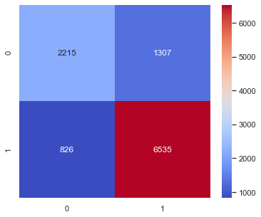

```python
sns.set(rc = {'figure.figsize':(6,5)})
sns.heatmap(confusion_matrix(y_test, pred), annot = True, fmt='d',cmap= 'coolwarm')
```

## Final Model Summary

```python
print(lg.summary())
```

```
                           Logit Regression Results
==============================================================================
Dep. Variable:                      y   No. Observations:                25392
Model:                          Logit   Df Residuals:                    25365
Method:                           MLE   Df Model:                           26
Date:                Mon, 06 Feb 2023   Pseudo R-squ.:                  0.3274
Time:                        11:24:39   Log-Likelihood:                -10822.
converged:                      False   LL-Null:                       -16091.
Covariance Type:            nonrobust   LLR p-value:                     0.000
========================================================================================================
                                           coef    std err          z      P>|z|      [0.025      0.975]
--------------------------------------------------------------------------------------------------------
no_of_adults                            -0.1009      0.038     -2.685      0.007      -0.175      -0.027
no_of_children                          -0.1629      0.057     -2.867      0.004      -0.274      -0.052
no_of_weekend_nights                    -0.1082      0.020     -5.478      0.000      -0.147      -0.069
no_of_week_nights                       -0.0405      0.012     -3.296      0.001      -0.065      -0.016
required_car_parking_space               1.6213      0.138     11.781      0.000       1.352       1.891
lead_time                               -0.0163      0.000    -63.030      0.000      -0.017      -0.016
arrival_year                             0.0012      0.000      9.205      0.000       0.001       0.001
arrival_month                            0.0615      0.006     10.261      0.000       0.050       0.073
arrival_date                            -0.0005      0.002     -0.234      0.815      -0.004       0.003
repeated_guest                           2.3698      0.609      3.892      0.000       1.176       3.563
no_of_previous_cancellations            -0.2667      0.086     -3.107      0.002      -0.435      -0.098
no_of_previous_bookings_not_canceled     0.1626      0.147      1.109      0.267      -0.125       0.450
avg_price_per_room                      -0.0201      0.001    -28.012      0.000      -0.022      -0.019
no_of_special_requests                   1.4550      0.030     48.644      0.000       1.396       1.514
type_of_meal_plan_Meal Plan 2           -0.0464      0.064     -0.724      0.469      -0.172       0.079
type_of_meal_plan_Meal Plan 3          -19.2937   1.23e+04     -0.002      0.999   -2.42e+04    2.42e+04
type_of_meal_plan_Not Selected          -0.3442      0.052     -6.571      0.000      -0.447      -0.242
room_type_reserved_Room_Type 2           0.3753      0.130      2.883      0.004       0.120       0.630
room_type_reserved_Room_Type 3          -0.0511      1.298     -0.039      0.969      -2.596       2.494
room_type_reserved_Room_Type 4           0.2599      0.053      4.903      0.000       0.156       0.364
room_type_reserved_Room_Type 5           0.6820      0.210      3.253      0.001       0.271       1.093
room_type_reserved_Room_Type 6           1.0239      0.146      7.010      0.000       0.738       1.310
room_type_reserved_Room_Type 7           1.4602      0.294      4.969      0.000       0.884       2.036
market_segment_type_Complementary       25.4264   1.23e+04      0.002      0.998   -2.42e+04    2.42e+04
market_segment_type_Corporate            1.3119      0.266      4.927      0.000       0.790       1.834
market_segment_type_Offline              2.3307      0.255      9.149      0.000       1.831       2.830
market_segment_type_Online               0.4995      0.252      1.985      0.047       0.006       0.993
========================================================================================================
```

## Building a Decision Tree model

```python
model = DecisionTreeClassifier(random_state=1)
model.fit(X_train, y_train)
```

```
DecisionTreeClassifier(random_state=1)
```

```python
#Train Metrics
train_pred = model.predict(X_train)

acc = accuracy_score(y_train, train_pred)  # to compute Accuracy
recall = recall_score(y_train, train_pred)  # to compute Recall
precision = precision_score(y_train, train_pred)  # to compute Precision
f1 = f1_score(y_train, train_pred)  # to compute F1-score

# creating a dataframe of metrics
train_df = pd.DataFrame(
    {"Accuracy": acc, "Recall": recall, "Precision": precision, "F1": f1,},
    index=[0],
)

#Test pred
test_pred = model.predict(X_test)

dt_acc = accuracy_score(y_test, test_pred)  # to compute Accuracy
dt_recall = recall_score(y_test, test_pred)  # to compute Recall
dt_precision = precision_score(y_test, test_pred)  # to compute Precision
dt_f1 = f1_score(y_test, pred)  # to compute F1-score

# creating a dataframe of metrics
test_df = pd.DataFrame(
    {"Accuracy": dt_acc, "Recall": dt_recall, "Precision": dt_precision, "F1": dt_f1,},
    index=[0],
)

print('Training Performance - ')
print(train_df)
print('Test Performance - ')
print(test_df)
```

[output not shown]

[figure not shown]

```python
sns.set(rc = {'figure.figsize':(6,5)})
sns.heatmap(confusion_matrix(y_test, pred), annot = True, fmt='d',cmap= 'coolwarm')
```

```python
print(classification_report(y_test, pred))
```

[output not shown]